# Introduction to Computer Vision: Twitter US Airline Sentiment

## Data Overview

The initial steps to get an overview of any dataset is to:

- Observe the first few rows of the dataset, to check whether the dataset has been loaded properly or not
- Get information about the number of rows and columns in the dataset
- Find out the data types of the columns to ensure that data is stored in the preferred format and the value of each property is as expected.

```python
df.info()
```

```
<class 'pandas.core.frame.DataFrame'>
RangeIndex: 14640 entries, 0 to 14639
Data columns (total 15 columns):
 #   Column                        Non-Null Count  Dtype
---  ------                        --------------  -----
 0   tweet_id                      14640 non-null  int64
 1   airline_sentiment             14640 non-null  object
 2   airline_sentiment_confidence  14640 non-null  float64
 3   negativereason                9178 non-null   object
 4   negativereason_confidence     10522 non-null  float64
 5   airline                       14640 non-null  object
 6   airline_sentiment_gold        40 non-null     object
 7   name                          14640 non-null  object
 8   negativereason_gold           32 non-null     object
 9   retweet_count                 14640 non-null  int64
 10  text                          14640 non-null  object
 11  tweet_coord                   1019 non-null   object
 12  tweet_created                 14640 non-null  object
 13  tweet_location                9907 non-null   object
 14  user_timezone                 9820 non-null   object
dtypes: float64(2), int64(2), object(11)
memory usage: 1.7+ MB
```

```python
df.head()
```

|  | tweet_id | airline_sentiment | airline_sentiment_confidence | negativereason | negativereason_confidence | airline | airline_sentiment_gold | name | negativereason_gold | retweet_count | text | tweet_coord | tweet_created | tweet_location | user_timezone |
| --- | --- | --- | --- | --- | --- | --- | --- | --- | --- | --- | --- | --- | --- | --- | --- |
| 0 | 570306133677760513 | neutral | 1.0000 | NaN | NaN | Virgin America | NaN | cairdin | NaN | 0 | @VirginAmerica What @dhepburn said. | NaN | 2015-02-24 11:35:52 -0800 | NaN | Eastern Time (US & Canada) |
| 1 | 570301130888122368 | positive | 0.3486 | NaN | 0.0000 | Virgin America | NaN | jnardino | NaN | 0 | @VirginAmerica plus you've added commercials t... | NaN | 2015-02-24 11:15:59 -0800 | NaN | Pacific Time (US & Canada) |
| 2 | 570301083672813571 | neutral | 0.6837 | NaN | NaN | Virgin America | NaN | yvonnalynn | NaN | 0 | @VirginAmerica I didn't today... Must mean I n... | NaN | 2015-02-24 11:15:48 -0800 | Lets Play | Central Time (US & Canada) |
| 3 | 570301031407624196 | negative | 1.0000 | Bad Flight | 0.7033 | Virgin America | NaN | jnardino | NaN | 0 | @VirginAmerica it's really aggressive to blast... | NaN | 2015-02-24 11:15:36 -0800 | NaN | Pacific Time (US & Canada) |
| 4 | 570300817074462722 | negative | 1.0000 | Can't Tell | 1.0000 | Virgin America | NaN | jnardino | NaN | 0 | @VirginAmerica and it's a really big bad thing... | NaN | 2015-02-24 11:14:45 -0800 | NaN | Pacific Time (US & Canada) |

The data set appears to have been loaded properly.

There are 15 columns and 14640 rows.

All columns seem to be in proper format and, aside from a significant number of missing values, all values seem to be in expected properties.

```python
# Delete unnecessary columns
df = df.drop(['tweet_id', 'name', 'tweet_coord', 'tweet_created', 'tweet_location', 'user_timezone', 'retweet_count'], axis=1)
```

```python
df.info()
```

```
<class 'pandas.core.frame.DataFrame'>
RangeIndex: 14640 entries, 0 to 14639
Data columns (total 8 columns):
 #   Column                        Non-Null Count  Dtype
---  ------                        --------------  -----
 0   airline_sentiment             14640 non-null  object
 1   airline_sentiment_confidence  14640 non-null  float64
 2   negativereason                9178 non-null   object
 3   negativereason_confidence     10522 non-null  float64
 4   airline                       14640 non-null  object
 5   airline_sentiment_gold        40 non-null     object
 6   negativereason_gold           32 non-null     object
 7   text                          14640 non-null  object
dtypes: float64(2), object(6)
memory usage: 915.1+ KB
```

```python
# Reload dataframe after deleting unneeded columns
df.head()
```

|  | airline_sentiment | airline_sentiment_confidence | negativereason | negativereason_confidence | airline | airline_sentiment_gold | negativereason_gold | text |
| --- | --- | --- | --- | --- | --- | --- | --- | --- |
| 0 | neutral | 1.0000 | NaN | NaN | Virgin America | NaN | NaN | @VirginAmerica What @dhepburn said. |
| 1 | positive | 0.3486 | NaN | 0.0000 | Virgin America | NaN | NaN | @VirginAmerica plus you've added commercials t... |
| 2 | neutral | 0.6837 | NaN | NaN | Virgin America | NaN | NaN | @VirginAmerica I didn't today... Must mean I n... |
| 3 | negative | 1.0000 | Bad Flight | 0.7033 | Virgin America | NaN | NaN | @VirginAmerica it's really aggressive to blast... |
| 4 | negative | 1.0000 | Can't Tell | 1.0000 | Virgin America | NaN | NaN | @VirginAmerica and it's a really big bad thing... |

```python
df.tail()
```

|  | airline_sentiment | airline_sentiment_confidence | negativereason | negativereason_confidence | airline | airline_sentiment_gold | negativereason_gold | text |
| --- | --- | --- | --- | --- | --- | --- | --- | --- |
| 14635 | positive | 0.3487 | NaN | 0.0000 | American | NaN | NaN | @AmericanAir thank you we got on a different f... |
| 14636 | negative | 1.0000 | Customer Service Issue | 1.0000 | American | NaN | NaN | @AmericanAir leaving over 20 minutes Late Flig... |
| 14637 | neutral | 1.0000 | NaN | NaN | American | NaN | NaN | @AmericanAir Please bring American Airlines to... |
| 14638 | negative | 1.0000 | Customer Service Issue | 0.6659 | American | NaN | NaN | @AmericanAir you have my money, you change my ... |
| 14639 | neutral | 0.6771 | NaN | 0.0000 | American | NaN | NaN | @AmericanAir we have 8 ppl so we need 2 know h... |

```python
df['airline_sentiment'].value_counts()
```

```
negative    9178
neutral     3099
positive    2363
Name: airline_sentiment, dtype: int64
```

Dropped unneeded columns and rechecked dataset.

## Exploratory Data Analysis

- EDA is an important part of any project involving data.
- It is important to investigate and understand the data better before building a model with it.
- A few questions have been mentioned below which will help you approach the analysis in the right manner and generate insights from the data.
- A thorough analysis of the data, in addition to the questions mentioned below, should be done.

**Questions**:

- What is the percentage of tweets for each airline?
- What is the distribution of sentiments across all the tweets?
- What is the distribution of sentiments for each airline?
- What does the plot of negative reasons indicate?
- How does a wordcloud appear for negative tweets?
- How does a wordcloud appear for positive tweets?
- What are insights observed from EDA?

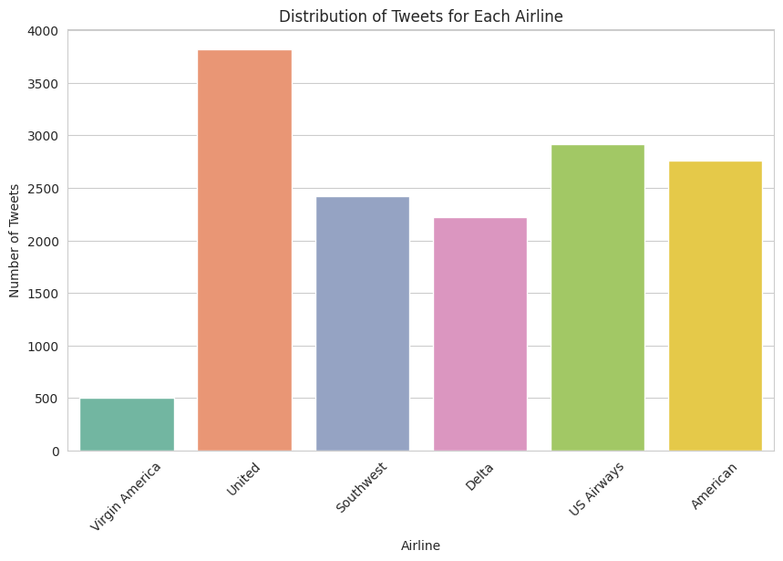

```
Percentage of Tweets for Each Airline:
United            26.11
US Airways        19.90
American          18.85
Southwest         16.53
Delta             15.18
Virgin America     3.44
Name: airline, dtype: float64
```

```python
# Calculate the percentage of tweets for each airline
airline_percentage = (df['airline'].value_counts() / len(df) * 100).round(2)

# Create distribution plot for tweets across all airlines
plt.figure(figsize=(10, 6))
sns.set_style("whitegrid")
sns.countplot(data=df, x='airline', palette='Set2')
plt.xlabel('Airline')
plt.ylabel('Number of Tweets')
plt.title('Distribution of Tweets for Each Airline')
plt.xticks(rotation=45)  # Rotate x-axis labels for better readability
plt.show()

# Print the percentage of tweets for each airline
print("Percentage of Tweets for Each Airline:")
print(airline_percentage)
```

The percentage of tweets for each airlines is as followed:

United 26.11%, US Airways 19.90%, American 18.85%, Southwest 16.53%, Delta 15.18%, Virgin America 3.44%

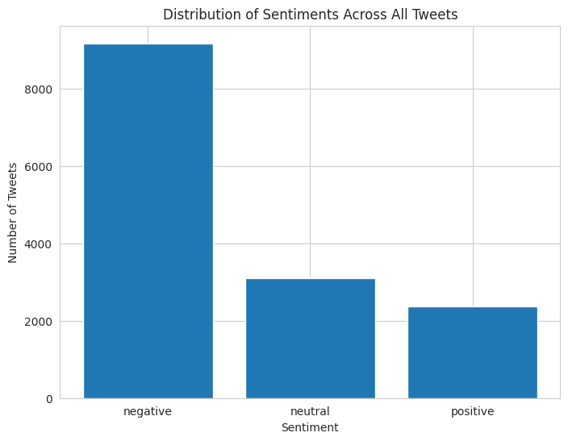

```
Percentage of Tweet Sentiments:
negative    62.69
neutral     21.17
positive    16.14
Name: airline_sentiment, dtype: float64
```

```python
# Create a bar chart to visualize the distribution of sentiments across all tweets

# Calculate the percentage of tweets for each airline
airline_percentage = df['airline'].value_counts() / len(df) * 100

# Create a bar chart to visualize the distribution of sentiments across all tweets
sentiment_counts = df['airline_sentiment'].value_counts()
plt.figure(figsize=(8, 6))
plt.bar(sentiment_counts.index, sentiment_counts.values)
plt.xlabel('Sentiment')
plt.ylabel('Number of Tweets')
plt.title('Distribution of Sentiments Across All Tweets')
plt.show()

# Calculate the percentage of each sentiment category
sentiment_percentage = (df['airline_sentiment'].value_counts(normalize=True) * 100).round(2)

# Display the results
print("Percentage of Tweet Sentiments:")
print(sentiment_percentage)
```

Tweets are 62.69% negative, 21.17% neutral, and 16.14% positive.

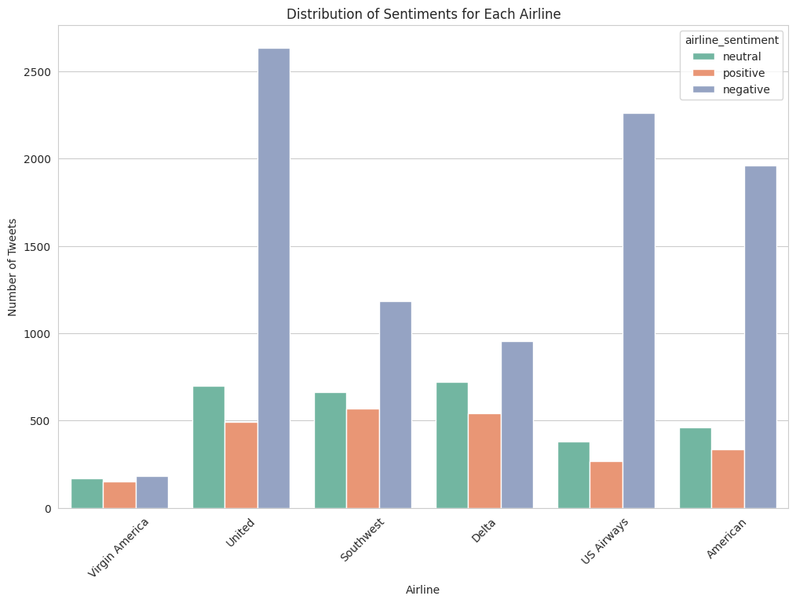

```
Percentage of Sentiment for Each Airline:
airline_sentiment  negative  neutral  positive
airline
American              71.04    16.78     12.18
Delta                 42.98    32.54     24.48
Southwest             49.01    27.44     23.55
US Airways            77.69    13.08      9.23
United                68.89    18.24     12.87
Virgin America        35.91    33.93     30.16
```

```python
# Create a grouped bar chart to visualize the distribution of sentiments for each airline
plt.figure(figsize=(12, 8))
sns.set_style("whitegrid")
sns.countplot(data=df, x='airline', hue='airline_sentiment', palette='Set2')

plt.xlabel('Airline')
plt.ylabel('Number of Tweets')
plt.title('Distribution of Sentiments for Each Airline')
plt.xticks(rotation=45)  # Rotate x-axis labels for better readability

plt.show()

# Group sentiment by airlines
sentiment_counts = df.groupby(['airline', 'airline_sentiment']).size().unstack(fill_value=0)

# Calculate the percentage of each sentiment category for each airline
sentiment_percentage = (sentiment_counts.div(sentiment_counts.sum(axis=1), axis=0) * 100).round(2)

# Display the results
print("Percentage of Sentiment for Each Airline:")
print(sentiment_percentage)
```

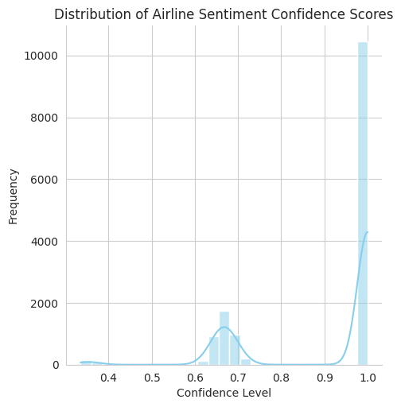

```python
# Create a displot for the "airline_sentiment_confidence" column
plt.figure(figsize=(10, 6))
sns.set_style("whitegrid")
sns.displot(df, x='airline_sentiment_confidence', kde=True, color='skyblue')

plt.xlabel('Confidence Level')
plt.ylabel('Frequency')
plt.title('Distribution of Airline Sentiment Confidence Scores')
plt.show()
```

Confidence scores are mostly in 1.0 range with a minority in the 0.6-0.7 range.

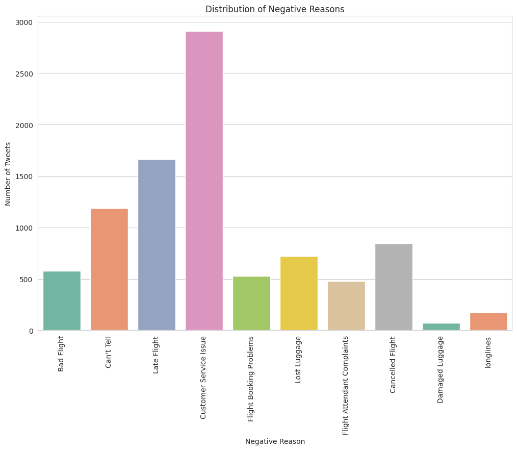

```
Percentage of each negative reason:
Customer Service Issue         31.71
Late Flight                    18.14
Can't Tell                     12.97
Cancelled Flight                9.23
Lost Luggage                    7.89
Bad Flight                      6.32
Flight Booking Problems         5.76
Flight Attendant Complaints     5.24
longlines                       1.94
Damaged Luggage                 0.81
Name: negativereason, dtype: float64
```

```python
# Create a countplot for the "negativereason" column
plt.figure(figsize=(12, 8))
sns.set_style("whitegrid")
sns.countplot(data=df, x='negativereason', palette='Set2')
plt.xlabel('Negative Reason')
plt.ylabel('Number of Tweets')
plt.title('Distribution of Negative Reasons')
plt.xticks(rotation=90)  # Rotate x-axis labels for better readability
plt.show()

# Calculate the percentage of each negative reason
negative_reason_percentage = (df['negativereason'].value_counts(normalize=True) * 100).round(2)

# Display the results
print("Percentage of each negative reason:")
print(negative_reason_percentage)
```

The most common negative reason mentioned in the tweets is "Customer Service Issue," accounting for approximately 31.71% of the negative sentiment expressed in the dataset. "Late Flight" follows as the second most prevalent reason at 18.14%. "Can't Tell" and "Cancelled Flight" represent 12.97% and 9.23% of the negative sentiment, respectively. Other negative reasons, such as "Lost Luggage," "Bad Flight," "Flight Booking Problems," "Flight Attendant Complaints," "longlines," and "Damaged Luggage," make up smaller proportions, ranging from 0.81% to 7.89%. These percentages provide insights into the primary causes of negative sentiment in the context of airline-related tweets.

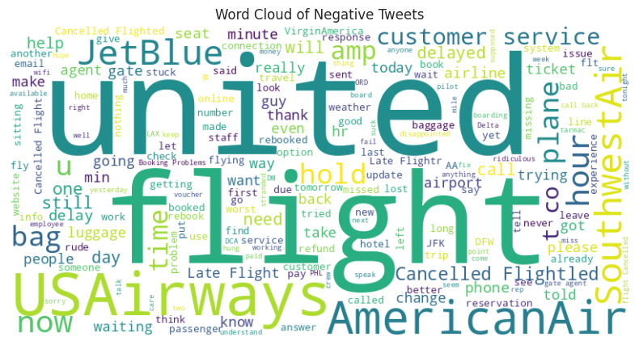

```python
# Filter only the negative tweets
negative_tweets = df[df['airline_sentiment'] == 'negative']['text']

# Combine negative tweets into a single text string
negative_text = " ".join(tweet for tweet in negative_tweets)

# Generate the word cloud
wordcloud_negative = WordCloud(width=800, height=400, background_color='white').generate(negative_text)

# Plot the word cloud
plt.figure(figsize=(10, 5))
plt.imshow(wordcloud_negative, interpolation='bilinear')
plt.axis('off')
plt.title('Word Cloud of Negative Tweets')
plt.show()
```

The words that stand out are: united, flight, USAirways, AmericanAir, SouthwestAir

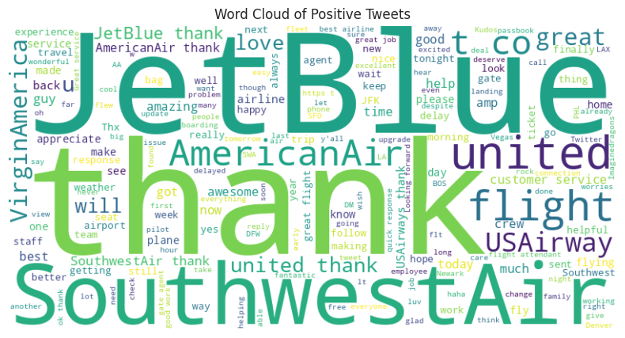

```python
# Filter only the positive tweets
positive_tweets = df[df['airline_sentiment'] == 'positive']['text']

# Combine negative tweets into a single text string
positive_text = " ".join(tweet for tweet in positive_tweets)

# Generate the word cloud
wordcloud_positive = WordCloud(width=800, height=400, background_color='white').generate(positive_text)

# Plot the word cloud
plt.figure(figsize=(10, 5))
plt.imshow(wordcloud_positive, interpolation='bilinear')
plt.axis('off')
plt.title('Word Cloud of Positive Tweets')
plt.show()
```

The words that stand out are: JetBlue, thank, flight, SouthwestAir, united, AmericanAir

Overall:

The vast majority of tweets are negative with confidence level being very high. Most people who tweet don't have good experiences flying with these airlines.

## Data Preparation for Modeling

- Drop all unnecessary columns
- Remove html tags
- Replace contractions in string(e.g. replace I'm --> I am) and so on.\
- Remove numbers
- Tokenization
- To remove Stopwords
- Lemmatized data

```python
# html tag removal
def remove_html_tags(text):
    clean = re.compile('<.*?>')
    return re.sub(clean, '', text)

# Apply unidecode to the 'text' column
df['text'] = df['text'].apply(lambda x: unidecode(x) if isinstance(x, str) else x)

df['text'] = df['text'].apply(remove_html_tags)

# Tokenization
df['text'] = df['text'].apply(word_tokenize)

# Remove numbers
df['text'] = df['text'].apply(lambda words: [word for word in words if not word.isnumeric()])

# Remove Special Characters and Punctuations
df['text'] = df['text'].apply(lambda words: [word for word in words if word.isalnum()])

# Remove stopwords
stop_words = set(stopwords.words('english'))
df['text'] = df['text'].apply(lambda words: [word for word in words if word.lower() not in stop_words])

# Conversion to lowercase
df['text'] = df['text'].apply(lambda words: [word.lower() for word in words])

# Lemmatize
lemmatizer = WordNetLemmatizer()
df['text'] = df['text'].apply(lambda words: [lemmatizer.lemmatize(word) for word in words])

# Join the words in the list to convert them back to text string
df['text'] = df['text'].apply(lambda words: ' '.join(words))

# Print the first 5 rows of data after pre-processing
df.head()
```

|  | airline_sentiment | airline_sentiment_confidence | negativereason | negativereason_confidence | airline | airline_sentiment_gold | negativereason_gold | text |
| --- | --- | --- | --- | --- | --- | --- | --- | --- |
| 0 | neutral | 1.0000 | NaN | NaN | Virgin America | NaN | NaN | virginamerica dhepburn said |
| 1 | positive | 0.3486 | NaN | 0.0000 | Virgin America | NaN | NaN | virginamerica plus added commercial experience... |
| 2 | neutral | 0.6837 | NaN | NaN | Virgin America | NaN | NaN | virginamerica today must mean need take anothe... |
| 3 | negative | 1.0000 | Bad Flight | 0.7033 | Virgin America | NaN | NaN | virginamerica really aggressive blast obnoxiou... |
| 4 | negative | 1.0000 | Can't Tell | 1.0000 | Virgin America | NaN | NaN | virginamerica really big bad thing |

## Model Building

### Using countvectorizer

- Intialize countvectorizer and use it for vectorization
- Store Independent and Dependent variables
- Split the data into train and test
- Build a Random Forest model on train data
- Use Cross validation to validate the score and to find optimal n_estimators
- Plot the misclassification error for each of estimators
- Test the model on testing data
- Plot the Confusion matrix plot word cloud for top 20 important features obtained from Count vectorizer and random forest model

```
Cross-validation scores: [0.7576 0.7554 0.7425 0.7566 0.7652]
Mean CV score: 0.7555
```

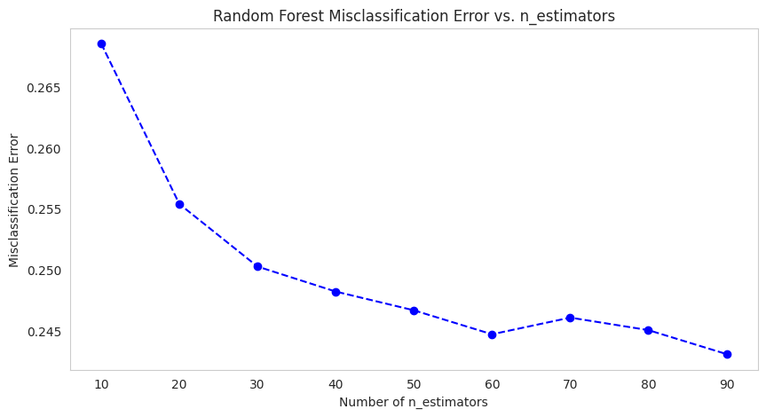

```
Test accuracy: 0.7612704918032787
```

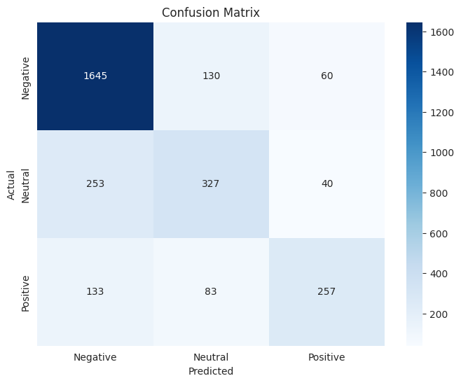

```
Classification Report:
              precision    recall  f1-score   support

    Negative       0.81      0.90      0.85      1835
     Neutral       0.61      0.53      0.56       620
    Positive       0.72      0.54      0.62       473

    accuracy                           0.76      2928
   macro avg       0.71      0.66      0.68      2928
weighted avg       0.75      0.76      0.75      2928
```

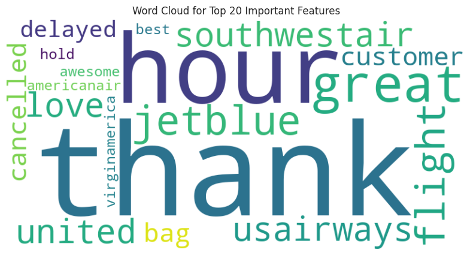

```python
# Initialize CountVectorizer and use it for vectorization
vectorizer = CountVectorizer()
X = vectorizer.fit_transform(df['text'])
y = df['airline_sentiment']

# Store Independent and Dependent variables
X = X.toarray()

# Split the data into train and test
X_train, X_test, y_train, y_test = train_test_split(X, y, test_size=0.2, random_state=42, stratify=y)

# Build a Random Forest model on train data
rf_model = RandomForestClassifier(n_estimators=100, random_state=42)
rf_model.fit(X_train, y_train)

# Use Cross-validation to validate the score and to find optimal n_estimators
scores = cross_val_score(rf_model, X_train, y_train, cv=5).round(4)
print("Cross-validation scores:", scores)
print("Mean CV score:", scores.mean().round(4))

# Plot the misclassification error for each number of estimators
n_estimators = range(10, 100, 10)
error_rate = []

for n in n_estimators:
    rf = RandomForestClassifier(n_estimators=n, random_state=42)
    scores = cross_val_score(rf, X_train, y_train, cv=5)
    error_rate.append(1 - scores.mean())

plt.figure(figsize=(10, 5))
plt.plot(n_estimators, error_rate, marker='o', linestyle='--', color='b')
plt.title("Random Forest Misclassification Error vs. n_estimators")
plt.xlabel("Number of n_estimators")
plt.ylabel("Misclassification Error")
plt.grid()
plt.show()

# Test the model on testing data
test_accuracy = rf_model.score(X_test, y_test)
print("Test accuracy:", test_accuracy)

# Get predictions from the model
y_pred = rf_model.predict(X_test)

# Create the confusion matrix
conf_matrix = confusion_matrix(y_test, y_pred)

# Display the confusion matrix using a heatmap
plt.figure(figsize=(8, 6))
sns.heatmap(conf_matrix, annot=True, fmt='d', cmap='Blues', xticklabels=['Negative', 'Neutral', 'Positive'], yticklabels=['Negative', 'Neutral', 'Positive'])
plt.xlabel('Predicted')
plt.ylabel('Actual')
plt.title('Confusion Matrix')
plt.show()

# Calculate and print the classification report
classification_rep = classification_report(y_test, y_pred, target_names=['Negative', 'Neutral', 'Positive'])
print("Classification Report:")
print(classification_rep)

# Plot Word Cloud for top 20 important features
feature_names = vectorizer.get_feature_names_out()
feature_importances = rf_model.feature_importances_

# Sort feature importances in descending order
sorted_indices = feature_importances.argsort()[::-1]

# Get the top 20 important features
top_feature_indices = sorted_indices[:20]
top_features = [feature_names[i] for i in top_feature_indices]

# Create a word cloud for top features
wordcloud = WordCloud(width=800, height=400, background_color='white').generate(' '.join(top_features))

plt.figure(figsize=(10, 5))
plt.imshow(wordcloud, interpolation='bilinear')
plt.axis('off')
plt.title('Word Cloud for Top 20 Important Features')
plt.show()
```

The random forest model built with CountVectorizer yielded encouraging results. During cross-validation, the model consistently achieved an average accuracy of 75.55%, indicating its robust performance. In the final test on a separate dataset, the model exhibited an accuracy of 76.13%, which is indicative of its ability to generalize well to unseen data. In terms of classification, the model excelled in identifying negative sentiment tweets, with a precision of 81% and strong recall of 90%. It also demonstrated moderate performance in classifying neutral and positive sentiment tweets. However, there is room for improvement in accurately classifying neutral and positive sentiment tweets, as both precision and recall scores for these categories are relatively lower. Overall, this model offers a solid foundation for sentiment analysis of tweets, with scope for fine-tuning to enhance its performance, especially in classifying neutral and positive sentiment tweets.

### Using TF-IDF (Term Frequency- Inverse Document Frequency)

- Intialize TFIDF and use it for vectorization
- Store Independent and Dependent variables
- Split the data into train and test
- Build a Random Forest model on train data
- Use Cross validation to validate the score and to find optimal n_estimators
- Plot the misclassification error for each of estimators
- Test the model on testing data
- Plot the Confusion matrix plot word cloud for top 20 important features obtained from TFIDF and random forest model

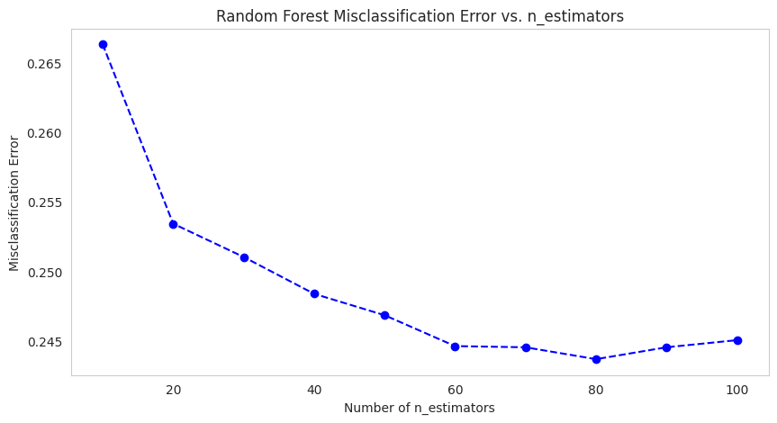

```
Test accuracy: 0.757172131147541
```

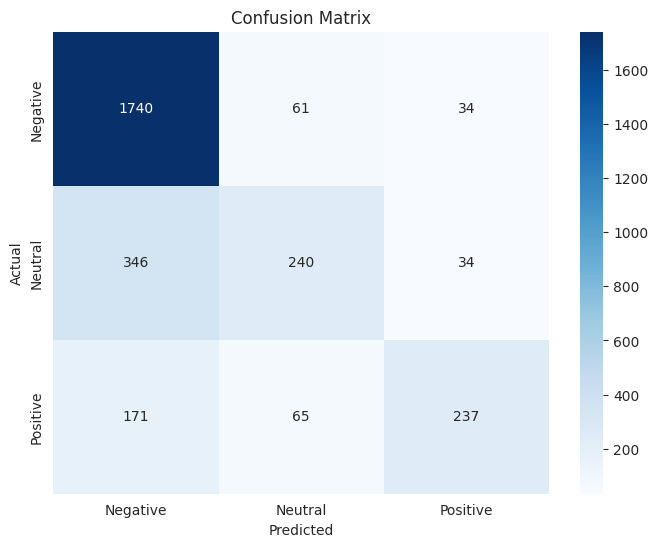

```
Classification Report:
              precision    recall  f1-score   support

    Negative       0.77      0.95      0.85      1835
     Neutral       0.66      0.39      0.49       620
    Positive       0.78      0.50      0.61       473

    accuracy                           0.76      2928
   macro avg       0.73      0.61      0.65      2928
weighted avg       0.75      0.76      0.73      2928
```

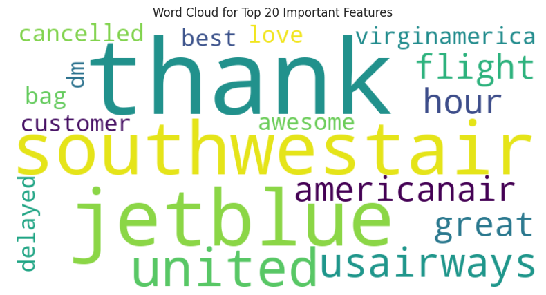

```python
# Initialize TF-IDF and use it for vectorization
vectorizer = TfidfVectorizer()
X = vectorizer.fit_transform(df['text'])
y = df['airline_sentiment']

# Store Independent and Dependent variables
X = X.toarray()

# Split the data into train and test
X_train, X_test, y_train, y_test = train_test_split(X, y, test_size=0.2, random_state=42, stratify=y)

# Build a Random Forest model on train data
rf_model2 = RandomForestClassifier(n_estimators=100, random_state=42)
rf_model2.fit(X_train, y_train)

# Use Cross-validation to validate the score and to find optimal n_estimators
n_estimators = range(10, 101, 10)
scores = []

for n in n_estimators:
    rf = RandomForestClassifier(n_estimators=n, random_state=42)
    scores.append(cross_val_score(rf, X_train, y_train, cv=5).mean())

# Plot the misclassification error for each number of estimators
plt.figure(figsize=(10, 5))
plt.plot(n_estimators, [1 - score for score in scores], marker='o', linestyle='--', color='b')
plt.title("Random Forest Misclassification Error vs. n_estimators")
plt.xlabel("Number of n_estimators")
plt.ylabel("Misclassification Error")
plt.grid()
plt.show()

# Test the model on testing data
test_accuracy = rf_model2.score(X_test, y_test)
print("Test accuracy:", test_accuracy)

# Get predictions from the model
y_pred = rf_model2.predict(X_test)

# Create the confusion matrix
conf_matrix = confusion_matrix(y_test, y_pred)

# Display the confusion matrix using a heatmap
plt.figure(figsize=(8, 6))
sns.heatmap(conf_matrix, annot=True, fmt='d', cmap='Blues', xticklabels=['Negative', 'Neutral', 'Positive'], yticklabels=['Negative', 'Neutral', 'Positive'])
plt.xlabel('Predicted')
plt.ylabel('Actual')
plt.title('Confusion Matrix')
plt.show()

# Calculate and print the classification report
classification_rep = classification_report(y_test, y_pred, target_names=['Negative', 'Neutral', 'Positive'])
print("Classification Report:")
print(classification_rep)

# Plot Word Cloud for top 20 important features
feature_names = vectorizer.get_feature_names_out()
feature_importances = rf_model2.feature_importances_

# Sort feature importances in descending order
sorted_indices = feature_importances.argsort()[::-1]

# Get the top 20 important features
top_feature_indices = sorted_indices[:20]
top_features = [feature_names[i] for i in top_feature_indices]

# Create a word cloud for top features
wordcloud = WordCloud(width=800, height=400, background_color='white').generate(' '.join(top_features))

plt.figure(figsize=(10, 5))
plt.imshow(wordcloud, interpolation='bilinear')
plt.axis('off')
plt.title('Word Cloud for Top 20 Important Features')
plt.show()
```

The random forest model built with TF-IDF produced promising results. In the final test on a separate dataset, the model achieved an accuracy of 75.72%, indicating its capability to generalize effectively to new data. The model excelled in correctly identifying negative sentiment tweets, with a precision of 77% and strong recall of 95%. It also demonstrated relatively better performance in classifying positive sentiment tweets, with a precision of 78% and a recall of 50%. However, there is room for improvement in classifying neutral sentiment tweets, where the model showed a lower precision of 66% and limited recall of 39%. Overall, this model provides a strong foundation for sentiment analysis, especially for negative and positive sentiment tweets, but further enhancements are needed to boost its performance in categorizing neutral sentiment tweets, achieving a more balanced and comprehensive sentiment analysis solution.

### Using LSTM

- Tokenize the text column
- Encode the target variable
- Split the data into train and test
- Train the LSTM model
- Test the model on train and test data
- Plot the confusion matrix

```
Train accuracy: 0.9602117538452148
Test accuracy: 0.7657103538513184
```

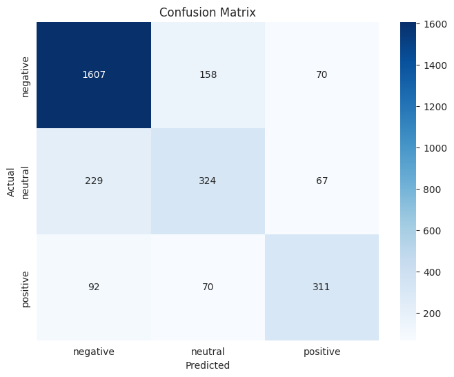

```
Classification Report:
               precision    recall  f1-score   support

    negative       0.83      0.88      0.85      1835
     neutral       0.59      0.52      0.55       620
    positive       0.69      0.66      0.68       473

    accuracy                           0.77      2928
   macro avg       0.70      0.69      0.69      2928
weighted avg       0.76      0.77      0.76      2928
```

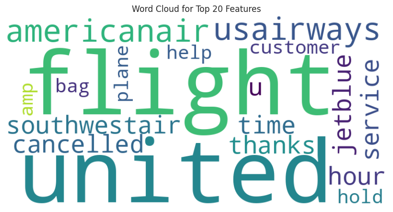

```python
# Tokenize the text column
tokenizer = Tokenizer(num_words=None)
tokenizer.fit_on_texts(df['text'])
X = tokenizer.texts_to_sequences(df['text'])
X = pad_sequences(X)

# Encode the target variable
label_encoder = LabelEncoder()
y_encoded = label_encoder.fit_transform(df['airline_sentiment'])

# Split the data into train and test
X_train, X_test, y_train, y_test = train_test_split(X, y_encoded, test_size=0.2, random_state=42, stratify=y_encoded)

# Train the LSTM model
model = Sequential()
model.add(Embedding(input_dim=len(tokenizer.word_index) + 1, output_dim=128, input_length=X.shape[1]))
model.add(LSTM(100))
model.add(Dense(3, activation='softmax'))

model.compile(loss='sparse_categorical_crossentropy', optimizer='adam', metrics=['accuracy'])
model.fit(X_train, y_train, epochs=5, batch_size=64)

# Test the model on train and test data
train_accuracy = model.evaluate(X_train, y_train, verbose=0)
test_accuracy = model.evaluate(X_test, y_test, verbose=0)
print("Train accuracy:", train_accuracy[1])
print("Test accuracy:", test_accuracy[1])

# Get predictions from the model
y_pred = model.predict(X_test)
y_pred_classes = y_pred.argmax(axis=-1)

# Create the confusion matrix
conf_matrix = confusion_matrix(y_test, y_pred_classes)

# Display the confusion matrix using a heatmap
plt.figure(figsize=(8, 6))
sns.heatmap(conf_matrix, annot=True, fmt='d', cmap='Blues', xticklabels=label_encoder.classes_, yticklabels=label_encoder.classes_)
plt.xlabel('Predicted')
plt.ylabel('Actual')
plt.title('Confusion Matrix')
plt.show()

# Calculate and print the classification report
class_report = classification_report(y_test, y_pred_classes, target_names=label_encoder.classes_)
print("Classification Report:\n", class_report)

# Create a word cloud for the top 20 features
top_20_features = list(tokenizer.word_index.keys())[:20]  # Adjust the number of features as needed
wordcloud_text = ' '.join(top_20_features)

wordcloud = WordCloud(width=800, height=400, background_color='white').generate(wordcloud_text)

plt.figure(figsize=(10, 5))
plt.imshow(wordcloud, interpolation='bilinear')
plt.axis('off')
plt.title('Word Cloud for Top 20 Features')
plt.show()
```

In terms of classification, the LSTM model exhibited strength in distinguishing negative sentiment tweets, achieving a precision of 83% and a robust recall of 88%. It also showcased moderate performance in categorizing positive sentiment tweets, with a precision of 69% and a recall of 66%. However, there is room for improvement in classifying neutral sentiment tweets, where the model demonstrated a precision of 59% and a recall of 52%. These results highlight the LSTM model's solid foundation for sentiment analysis, particularly in recognizing negative and positive sentiments. Yet, there is potential for further refinement to enhance its capability to classify neutral sentiment tweets more accurately, making it a well-rounded and comprehensive sentiment analysis solution.

## Summary

Random Forest Model with CountVectorizer:

Test Accuracy: 76.13% Strong performance in classifying negative sentiment tweets with a precision of 81% and recall of 90%. Moderate performance in classifying neutral and positive sentiment tweets. Average Cross-Validation Score: 75.55%.

Random Forest Model with TF-IDF:

Test Accuracy: 75.72% Strong performance in classifying negative sentiment tweets with a precision of 77% and recall of 95%. Moderate performance in classifying positive sentiment tweets. Moderate performance in classifying neutral sentiment tweets.

LSTM Model:

Test Accuracy: 76.57% Impressive training accuracy of approximately 96.02%. Strong performance in classifying negative sentiment tweets with a precision of 83% and recall of 88%. Moderate performance in classifying positive sentiment tweets. Room for improvement in classifying neutral sentiment tweets.

Comparison:

All three models demonstrated strong performance in classifying negative sentiment tweets. The LSTM model showed the highest accuracy, but the Random Forest model with TF-IDF had the highest recall for negative sentiment, suggesting it is better at capturing all negative sentiment tweets.

For positive sentiment classification, the Random Forest model with CountVectorizer had a balanced performance, with a precision of 72% and recall of 54%. The LSTM model also showed balanced performance, with a precision of 69% and recall of 66%. In contrast, the Random Forest model with TF-IDF had a high precision (78%) but a lower recall (50%).

In summary, the choice of model may depend on the specific goals and trade-offs in precision and recall. The LSTM model exhibited the highest overall test accuracy, while the Random Forest model with TF-IDF excelled in capturing negative sentiment. Fine-tuning and additional data preprocessing may further improve the models' performance in distinguishing neutral sentiment tweets.

```python
%%shell
jupyter nbconvert /content/drive/MyDrive/NLP_Learner_Notebook_Full_code_version.ipynb --to html
```

```
[NbConvertApp] Converting notebook /content/drive/MyDrive/NLP_Learner_Notebook_Full_code_version.ipynb to html
[NbConvertApp] Writing 2385255 bytes to /content/drive/MyDrive/NLP_Learner_Notebook_Full_code_version.html
```